# Practical 4 – Stationarity

Forecasting with Applications in Business (S411031) – Fall Semester 2026

Edouard

2026-10-12

```r
library(ggplot2)
library(dplyr)
library(tidyr)
library(forecast)
set.seed(42)
```

# Recall

## Strong stationarity

The process $(Y_t)_t$ with values in $\mathbb{R}^n$ is said to be **strongly stationary** if, for any $s \geq 1$, and $t_1 \leqslant t_2 \leqslant \ldots \leqslant t_s$, and all integers $k$, the joint distribution of $(Y_{t_1}, Y_{t_2}, \ldots, Y_{t_s})$ is the same as that of $(Y_{t_1+k}, Y_{t_2+k}, \ldots, Y_{t_s+k})$.

## Weak stationarity

The process $(Y_t)_t$ with values in $\mathbb{R}$ is said to be **weakly stationary** if, for any integer $s \geq 1$, and $t_1 \leqslant t_2 \leqslant \ldots \leqslant t_s$, and all integer $k$, all the joint moments of order one and two of $(Y_{t_1}, Y_{t_2}, \ldots, Y_{t_s})$ exist, are finite, and equal to the corresponding joint moments of $(Y_{t_1+k}, Y_{t_2+k}, \ldots, Y_{t_s+k})$. Specifically, for any $t$ such that $t_1 \leqslant t \leqslant t_s$,

$$\mathbb{E}[Y_t] \equiv \mu$$

is a constant independent of $t$;

for any $s$ and $t$, the autocovariance function $\gamma(s, t)$ depends on $s$ and $t$ only through their difference $|s - t|$.

# Exercise 1. Strongly Stationary Process

Consider the discrete-time stochastic process

$$Y_t \overset{\text{i.i.d.}}{\sim}
\mathcal{N}(0, 1), \quad t \geq 1.$$

**(a)** Simulate $Y_t$ for $t = 1, \ldots, 500$ and plot the resulting time series.

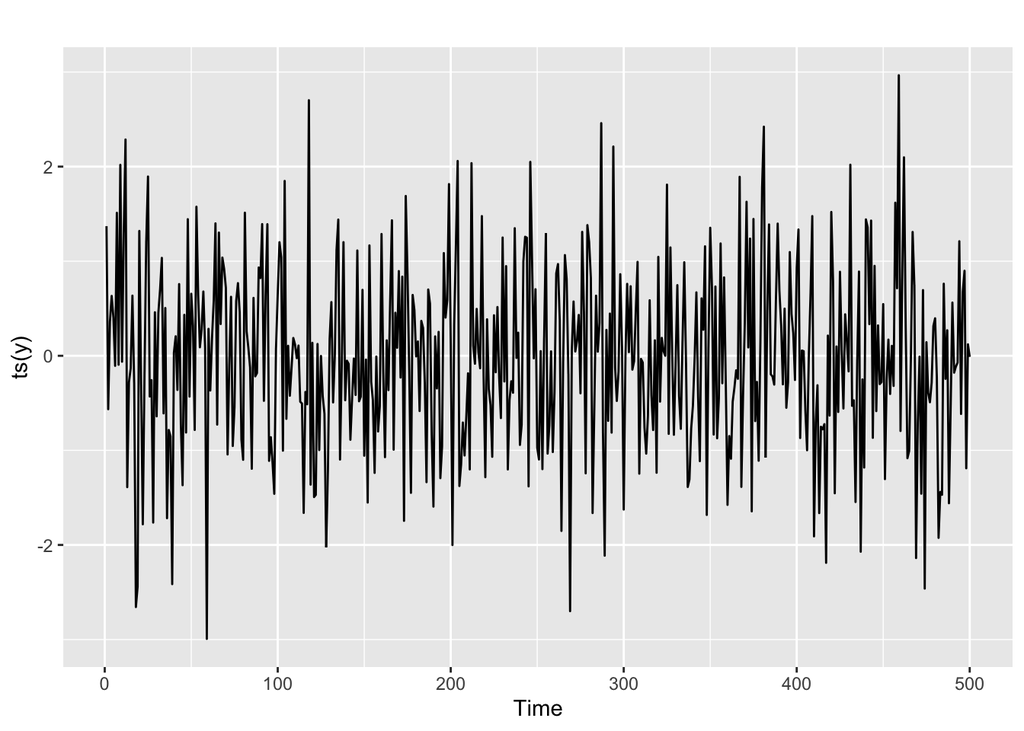

```r
n <- 500
y <- rnorm(n, 0, 1)
autoplot(ts(y))
```

**(b)** Generate multiple realizations of the process and compute the empirical mean and variance of $Y_t$. Check that they are approximately constant across $t$.

```r
n <- 500
n_sim <- 100

Y <- matrix(rnorm(n_sim * n, 0, 1), nrow = n_sim, ncol = n)

emp_mean <- colMeans(Y)
emp_var <- apply(Y,2, var)
summary(emp_mean)
```

```
##      Min.   1st Qu.    Median      Mean   3rd Qu.      Max.
## -0.252913 -0.073682  0.001215 -0.002213  0.064829  0.283238
```

```r
summary(emp_var)
```

```
##    Min. 1st Qu.  Median    Mean 3rd Qu.    Max.
##  0.6441  0.9031  1.0021  1.0107  1.1021  1.5912
```

**(c)** Explain why the process is both weakly stationary and strongly stationary, using the definitions of weak and strong stationarity.

since $Y_t$ are i.i.d.$\mathcal{N}(0,1)$ for any $s \ge 1$, $t_1 \leqslant t_2 \leqslant \ldots \leqslant t_s$ and any integer $k$, joint density of $(Y_{t_1}, \dots,Y_{t_s}$ is

$$f(y_1, \ldots, y_s) = \prod_{i=1}^{s}
\phi(y_i),$$
where $\phi$ is the standard normal density. The same holds for $(Y_{t_1+k}, \ldots, Y_{t_s+k})$. The joint distributions are therefore identical, i.e. $(Y_{t_1}, \ldots, Y_{t_s}) \sim \mathcal{N}(0, I_s)$ for any shift $k$, so the process is strongly stationary.

When it come to week stationarity, $\mathbb{E}[Y_t] = 0 \quad\forall t$ since each $Y_t \sim \mathcal{N}(0, 1)$ that give $\mu = 0$ witch does not depend on $t$.

second condtion to week stationarity, we need the autocovariance to only depend on $|s -t|$, $\gamma(s,t) = \text{Cov}(Y_s, Y_t)$:

If $s = t$: $\gamma(t,t) = \text{Var}(Y_t) = 1$. If $s \neq t$: $Y_s$ and $Y_t$ are independent, so $\gamma(s,t) = 0$.

So $\gamma(s,t) = \mathbb{1}\{|s-t| = 0\}$, which depends only on $|s-t|$.

# Exercise 2. Weakly Stationary Process

Consider the discrete-time stochastic process

$$Y_t = \cos(tU), \quad t \geq
1,$$

where $U \sim \text{Uniform}(-\pi, \pi)$.

**(a)** Simulate $Y_t$ for $t = 1, \ldots, 500$ by first sampling a single value of $U$ from $\text{Uniform}(-\pi, \pi)$ and then computing $Y_t = \cos(tU)$ for all $t$. Plot the resulting time series.

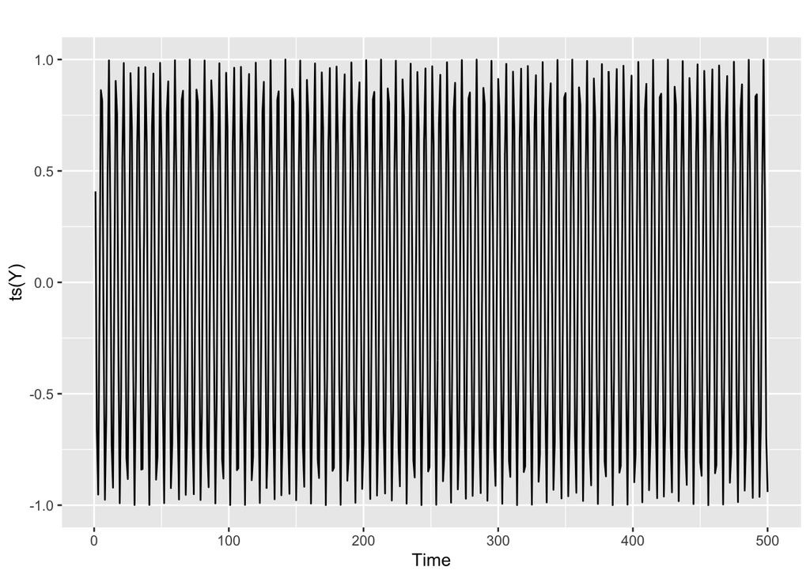

```r
set.seed(16)
n <- 500
t <- 1:n
u <- runif(1, min = - pi, max = pi)
Y <- cos(t*u)
autoplot(ts(Y))
```

**(b)** Generate multiple realizations of the process and compute the empirical mean and variance of $Y_t$. Check that they are approximately constant across $t$.

```r
set.seed(123)
n <- 500
n_sim <- 100
t <- 1:n

u <- runif(n_sim, min = -pi, max = pi)   # one U per realization
Y <- cos(outer(u, t))                     # n_sim x n matrix: row = realization, column = t

summary(colMeans(Y))
```

```
##       Min.    1st Qu.     Median       Mean    3rd Qu.       Max.
## -0.2318854 -0.0497482  0.0009914 -0.0010603  0.0443907  0.1901231
```

```r
summary(apply(Y, 2 , var))
```

```
##    Min. 1st Qu.  Median    Mean 3rd Qu.    Max.
##  0.4028  0.4756  0.4971  0.4983  0.5207  0.5986
```

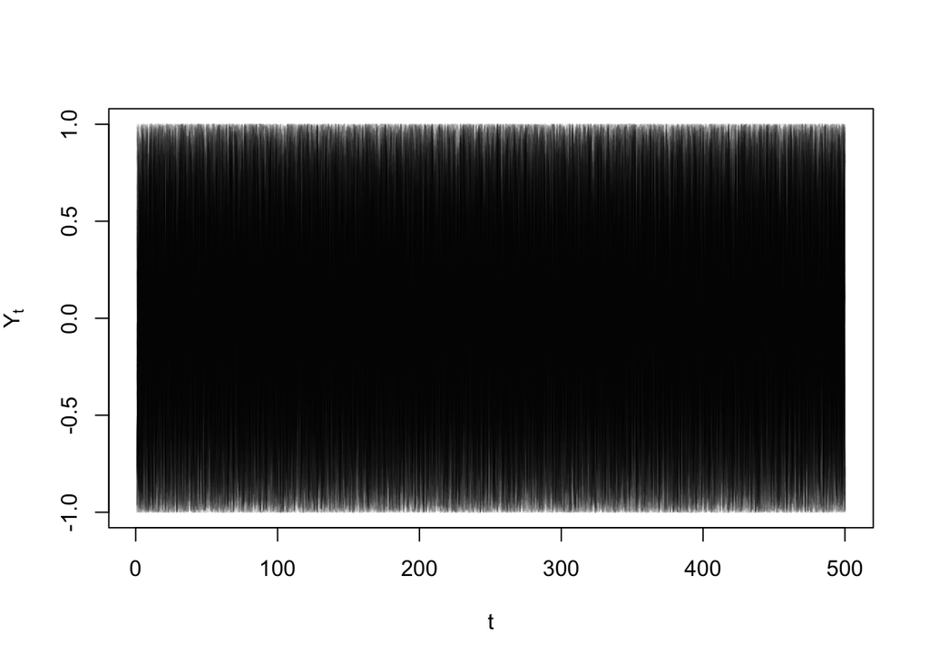

```r
matplot(t, t(Y), type = "l", lty = 1, col = rgb(0, 0, 0, 0.1),
        xlab = "t", ylab = expression(Y[t]))
```

**(c)** Show that the process is weakly stationary.

This process is weakly stationary because $\mathbb{E}[Y_t]= 0$ because the expections of cosines of uniform distibtuions are 0. thus $\mu = 0$. and the expection of $Y_t$ does not depend on $t$. thus first condition of weak stationarity hold ($\mathbb{E}[Y_t] \equiv 0$)

now for the second codition, we need the autocorrelation to depend only on $|s-t| \quad \forall \gamma(s,t)$. two cases: $s=t$ where $\gamma(s,s)=var(Y_t)$
$$Var(Y_t) =
\mathbb{E}[Y^2_t]-(\mathbb{E}[Y_t])^2=\mathbb{E}[\cos^2(tU)]$$
using the identity $\cos^2= \frac{1+\cos(2x)}{2}$
$$\mathbb{E}[\cos^2(tU)] = \frac{1}{2} +
\frac{1}{2}\,\mathbb{E}[\cos(2tU)]=\frac{1}{2}.$$
now when it comes to $\gamma(s,t)$
$$\gamma(s,t) = \text{Cov}(Y_s, Y_t) =
\mathbb{E}[Y_s Y_t] = \mathbb{E}[\cos(sU)\cos(tU)].$$
$$\gamma(s,t) =
\tfrac{1}{2}\,\mathbb{E}[\cos((s-t)U)] +
\tfrac{1}{2}\,\mathbb{E}[\cos((s+t)U)].$$

$$\gamma(s,t) = \begin{cases} \tfrac{1}{2}
& \text{if } s = t \\ 0 & \text{if } s \neq t
\end{cases}$$

This depends only on $|s-t|$, and it matches the variance of $\frac{1}{2}$. Combined with the constant mean, that proves weak stationarity.

**(d)** Show that the process is not strongly stationary. *Hint:* Consider the third-order moments

$$\mathbb{E}[Y_1 Y_2 Y_3] = \frac{1}{2\pi}
\int_{-\pi}^{\pi} \cos(U)\cos(2U)\cos(3U)\, dU.$$

Use the identity

$$\cos(a)\cos(b)\cos(c) =
\frac{1}{4}\Big(\cos(a+b+c) + \cos(a+b-c) + \cos(a-b+c) +
\cos(a-b-c)\Big),$$

and similarly with $\mathbb{E}[Y_2 Y_3 Y_4]$.

prove $Y_{t} = \cos(tU), t \geq 1$ is **not** strongly stationary where $U \sim U(-\pi,\pi)$ prove by counter example:
$$\mathbb{E}[Y_{1}Y_{2}Y_{3}] \neq
\mathbb{E}[Y_{2}Y_{3}Y_{4}]$$
if this unequality holds, $Y_{t}$ is not strongly stationary because the joint distribution $(Y_{t_{1}}, Y_{t_{2}},\dots, Y_{t_{s}})$ whould not be the same as of $(Y_{t_{1}+k}, Y_{t_{2}+k},\dots, Y_{t_{s}+k})$ for $k=1$

lets start by finding $\mathbb{E}[Y_{1}Y_{2}Y_{3}]$

$$\mathbb{E}[Y_{1}Y_{2}Y_{3}]=\frac{1}{2\pi}\int^\pi_{-\pi}\cos(U)+\cos(2U)+\cos(3U)du$$

$$\Leftrightarrow
\frac{1}{2\pi}\int^\pi_{-\pi} \frac{1}{4}
(\cos(u+2u+3u)+\cos(u+2u-3u)+\cos(u-2u+3u)+\cos(u-2u-3u))du$$

$$\Leftrightarrow \frac{1}{2\pi}
\int^\pi_{-\pi} \frac{1}{4}
(\cos(6u)+\cos(0)+\cos(2u)+\cos(-4u))$$
$$\Leftrightarrow \frac{1}{2\pi} \cdot \frac{1}{4}
\left( \int \cos(6u)\, \mathrm{d}u + \int \cos(0)\, \mathrm{d}u + \int
\cos(2u)\, \mathrm{d}u + \int \cos(-4u)\, \mathrm{d}u \right)$$
$$\Leftrightarrow \frac{1}{2\pi} \cdot
\frac{1}{4} \left(
\frac{\sin(6u)}{6}+u+\frac{\sin(2u)}{2}+\frac{\sin(4u)}{4} \biggr
|^\pi_{-\pi} \right)$$

$$\Leftrightarrow \frac{1}{2\pi} \cdot
\frac{1}{4} \left( \left[\frac{\sin(6\pi)}{6} + \pi +
\frac{\sin(2\pi)}{2} + \frac{\sin(4\pi)}{4}\right] -
\left[\frac{\sin(-6\pi)}{6} - \pi + \frac{\sin(-2\pi)}{2} +
\frac{\sin(-4\pi)}{4}\right] \right)$$
$$\Leftrightarrow \frac{1}{2\pi} \cdot
\frac{1}{4} \left( \left[0 + \pi + 0 + 0\right] - \left[0 - \pi + 0 +
0\right] \right)$$
$$\Leftrightarrow
\frac{1}{8\pi} \cdot 2\pi =\frac{1}{4}$$

now we find $\mathbb{E}[Y_{2}Y_{3}Y_{4}]$
$$\mathbb{E}[Y_{2}Y_{3}Y_{4}]=\frac{1}{2\pi}\int^\pi_{-\pi}\cos(2u)\cos(3u)\cos(4u)\,\mathrm{d}u$$
$$\Leftrightarrow
\frac{1}{2\pi}\int^\pi_{-\pi} \frac{1}{4}
(\cos(2u+3u+4u)+\cos(2u+3u-4u)+\cos(2u-3u+4u)+\cos(2u-3u-4u))\,\mathrm{d}u$$

$$\Leftrightarrow \frac{1}{2\pi}
\int^\pi_{-\pi} \frac{1}{4}
(\cos(9u)+\cos(u)+\cos(3u)+\cos(-5u))\,\mathrm{d}u$$

$$\Leftrightarrow \frac{1}{2\pi} \cdot
\frac{1}{4} \left( \int \cos(9u)\, \mathrm{d}u + \int \cos(u)\,
\mathrm{d}u + \int \cos(3u)\, \mathrm{d}u + \int \cos(-5u)\, \mathrm{d}u
\right)$$

$$\Leftrightarrow \frac{1}{2\pi} \cdot
\frac{1}{4} \left(
\frac{\sin(9u)}{9}+\sin(u)+\frac{\sin(3u)}{3}+\frac{\sin(5u)}{5} \biggr
|^\pi_{-\pi} \right)$$

$$\Leftrightarrow \frac{1}{2\pi} \cdot
\frac{1}{4} \left( \left[\frac{\sin(9\pi)}{9} + \sin(\pi) +
\frac{\sin(3\pi)}{3} + \frac{\sin(5\pi)}{5}\right] -
\left[\frac{\sin(-9\pi)}{9} + \sin(-\pi) + \frac{\sin(-3\pi)}{3} +
\frac{\sin(-5\pi)}{5}\right] \right)$$

$$\Leftrightarrow \frac{1}{2\pi} \cdot
\frac{1}{4} \left( \left[0 + 0 + 0 + 0\right] - \left[0 + 0 + 0 +
0\right] \right)$$

$$\Leftrightarrow \frac{1}{8\pi} \cdot 0 =
0$$
hence
$$\mathbb{E}[Y_{1}Y_{2}Y_{3}] = \frac{1}{4} \neq 0
= \mathbb{E}[Y_{2}Y_{3}Y_{4}],$$
so the joint distributions of $(Y_{1}, Y_{2}, Y_{3})$ differ from $(Y_{2},Y_{3}, Y_{4})$ thus $Y_{t}$ is not strongly stationary.

# Exercise 3. Non-Stationary Process

Consider the discrete-time stochastic process

$$S_t = \sum_{i=1}^{t} Y_i, \quad t \geq
1,$$

where $Y_i \overset{\text{i.i.d.}}{\sim} \mathcal{N}(0, \sigma^2)$. This defines a simple random walk.

**(a)** Simulate a realization of $S_t$ for $t = 1, \ldots, 500$ and plot the resulting time series.

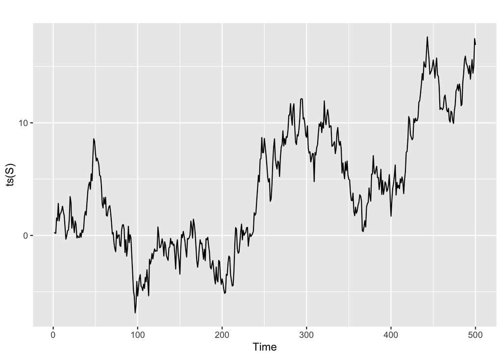

```r
n= 500
Y = rnorm(n,0, 1)
S = cumsum(Y)

autoplot(ts(S))
```

**(b)** Generate multiple realizations of the process and compute the empirical mean and variance of $S_t$ at each time $t$. Plot the variance as a function of $t$.

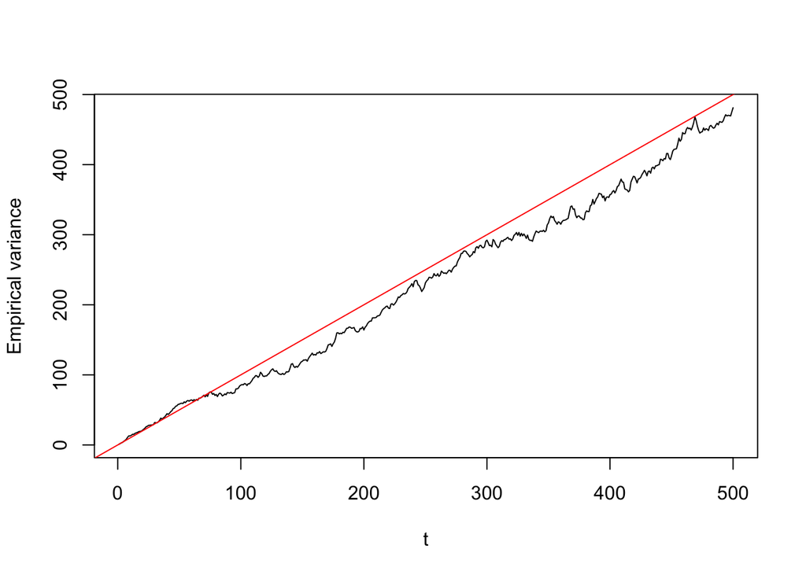

```r
num_sim <- 100
n <- 500

Y <- matrix(rnorm(num_sim * n, 0, 1), nrow = num_sim, ncol = n)
S <- t(apply(Y, 1, cumsum))   # each row is one random walk

emp_var <- apply(S, 2, var)

plot(1:n, emp_var, type = "l", xlab = "t", ylab = "Empirical variance")
abline(a = 0, b = 1, col = "red")   # theoretical Var(S_t) = t * sigma^2, here sigma = 1
```

**(c)** Compute the autocovariance function of the process. Is this process weakly stationary?

First, the mean:

$$\mathbb{E}[S_t] =
\mathbb{E}\left[\sum_{i=1}^{t} Y_i\right] = \sum_{i=1}^{t}
\mathbb{E}[Y_i] = 0 \quad \forall t,$$

so the mean is constant. Now the autocovariance, taking $s \leq t$ without loss of generality. We can split $S_t$ as

$$S_t = S_s + \sum_{i=s+1}^{t}
Y_i.$$

Then

$$\begin{aligned}
\gamma(s,t) &= \mathrm{Cov}(S_s, S_t) \\
&= \mathrm{Cov}\left(S_s,\, S_s + \sum_{i=s+1}^{t} Y_i\right) \\
&= \mathrm{Cov}(S_s, S_s) + \mathrm{Cov}\left(S_s,\,
\sum_{i=s+1}^{t} Y_i\right).
\end{aligned}$$

The second term is $0$, since $S_s$ depends only on $Y_1, \dots, Y_s$, which are independent of $Y_{s+1}, \dots, Y_t$. By independence of the $Y_i$, the first term is

$$\mathrm{Var}(S_s) = \sum_{i=1}^{s}
\mathrm{Var}(Y_i) = s\sigma^2.$$

Hence

$$\gamma(s,t) = \sigma^2
\min(s,t).$$

This depends on $\min(s,t)$ and not only on $|s-t|$. For example, with the same lag $|s-t| = 1$:

$$\gamma(1,2) = \sigma^2 \neq 10\sigma^2 =
\gamma(10,11).$$

In particular, $\mathrm{Var}(S_t) = \gamma(t,t) = t\sigma^2$ grows with $t$, as seen in the variance plot in (b). Therefore $S_t$ is **not weakly stationary**.